# Project: Exploratory data analysis of PISA 2012 data

## by Daniel Leirer

- Introduction
- Settings and Libraries
- Univariate Exploration
- Bivariate Exploration
- Multivariate Exploration

## Introduction

This is part of the "communicating data findings" project for the udacity data analyst nanodegree.  
This notebook contains the initial data exploration. See readme for more information.

The dataset explored in this analysis is the 2012 PISA data. This data is associated to two files. The main data (pisa2012.csv) and a dictionary (pisadict2012.csv) for all the columns. Since the pisa data is quite large, I manually added a collumn to the dictionary file which indicates the columns I thought might be of interest.

The focus of this analysis will be to look at gender differences in academic achievement and look at interactions with subjective sense of belonging.

I will look at gaps in achievement between the two genders by country and then use correlations to guide further analysis.

## Settings & Libraries:

### Import Packages

```python
import os
import numpy as np
import pandas as pd
import matplotlib.pyplot as plt
import seaborn as sns

#magic for matplotlib
%matplotlib inline

#settings for pandas
pd.set_option("display.max_columns",50)
pd.set_option('display.max_colwidth', -1)
```

```python
#make data folder
data_dir = "data"
if not os.path.exists(data_dir):
    os.makedirs(data_dir)
```

### Get Pisa 2012 data

Read csv file for dictionary and main file. The dictionary file contains a manually added column called "columnwant" which indicates columns that might be of interest for this analysis.

```python
#read in dictionary with columns to keep.
dictionary_filename = os.path.join(data_dir,"pisadict2012want.csv")
df_pdic = pd.read_csv(dictionary_filename, sep=",",encoding = "ISO-8859-1")
```

```python
#Check how many columns to keep
df_pdic.columnwant.value_counts()
#create list of columns to keep.
df_pdic = df_pdic.loc[df_pdic["columnwant"] == "y",:]
column_names_list= df_pdic.column_names
```

```python
#load pisa data limited to selected columns.
pisa_filename = os.path.join(data_dir,"pisa2012.csv")

#df_pisa = pd.read_csv(pisa_filename,sep=",",encoding = "ISO-8859-1",index_col=0)
df_pisa_full = pd.read_csv(pisa_filename,sep=",",encoding = "ISO-8859-1",index_col=0, usecols = column_names_list)
```

### What is the structure of your dataset?

The pisa data contains 485490 rows indicating unique students and 636 columns of information. Prior to the analysis I manaually selected 96 columns in the dictionary.

The columns included fall into the following categories

1. demographic information.
2. the level 5 maths, reading and science scores.
3. the summary columns for questionairs.
4. the full questionaire information for:
   1. "sense of belonging"
   2. "attitude towards school"
   3. "percieved control"
   4. "perseverence"

### What is/are the main feature(s) of interest in your dataset?

1. Gender (ST04Q01)
2. Math, Reading and Science scores (PV5MATH,PV5READ,PV5SCI)

### What features in the dataset do you think will help support your investigation into your feature(s) of interest?

I think Wealth and feature relating to social well being will be of interest, but my aim is to let the data speak for itself, by using correlations. Because of this approach I do not know in advance what features will be important for my investigation, and I might add features throughout the analysis.

## Univariate Exploration

### Gender

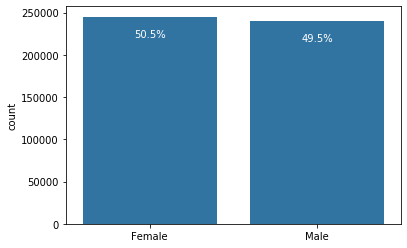

```python
#plot gender data


#plot settings
base_color = sns.color_palette()[0]
#Gender
sns.countplot(x="ST04Q01", data=df_pisa_full, color = base_color)
#remove xlabel
plt.xlabel("")

# add annotations
n_points = df_pisa_full.shape[0]
cat_counts = df_pisa_full["ST04Q01"].value_counts()
locs, labels = plt.xticks() # get the current tick locations and labels


# loop through each pair of locations and labels
for loc,label in zip(locs, labels):

    # get the text property for the label to get the correct count
    count = cat_counts[label.get_text()]
    pct_string = '{:0.1f}%'.format(100*count/n_points)

    # print the annotation just below the top of the bar
    plt.text(loc,count-count/10, pct_string, ha = 'center', color = 'w')
```

There are slightly more women than men overall. Next I will quickly look at the distribution of grades for Maths, Science and Reading.

#### Math, Reading and Science

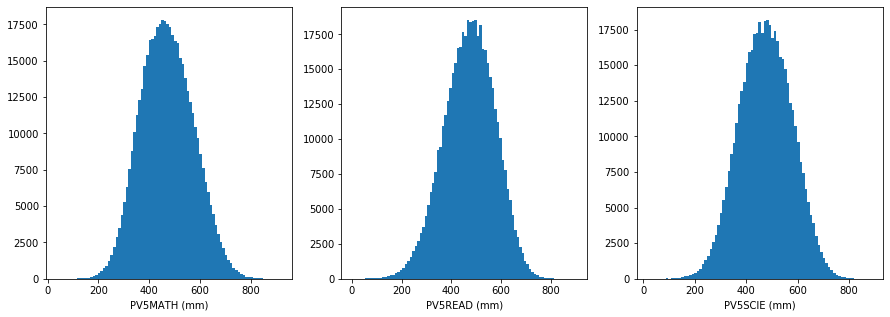

```python
# re-plot the distribution of x, y, and z.
fig, ax = plt.subplots(ncols=3, figsize = [15,5])

variables = ["PV5MATH","PV5READ" ,"PV5SCIE"]
for i in range(len(variables)):
    var = variables[i]
    bins = np.arange(min(df_pisa_full[var]), max(df_pisa_full[var])+10, 10)
    ax[i].hist(data = df_pisa_full, x = var, bins = bins)
    ax[i].set_xlabel('{} (mm)'.format(var))

plt.show()
```

Math Reading and Science scores are pretty much normally distributed.

### Country

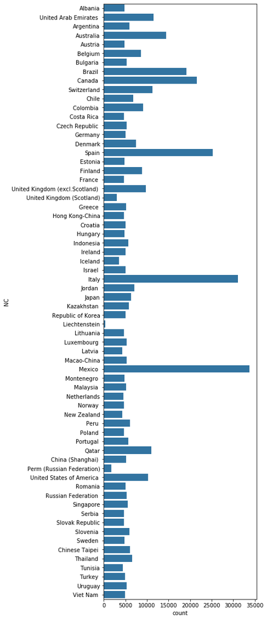

```python
# plot country information
plt.figure(figsize = [5,20 ])
base_color = sns.color_palette()[0]
sns.countplot(y="NC", data=df_pisa_full,color = base_color)
```

The Countries with the most students are Mexico Spain and Italy.

### Discuss the distribution(s) of your variable(s) of interest. Were there any unusual points? Did you need to perform any transformations?

Not at this point however if I subset to certain countries or other features this might be neccesary

### Of the features you investigated, were there any unusual distributions? Did you perform any operations on the data to tidy, adjust, or change the form of the data? If so, why did you do this?

Nope not at this point

## Bivariate Exploration

### Proporition of Male students by country

First lets add dummy variable to gender.

```python
#add gender dummy variable
gender_dummies=pd.get_dummies(df_pisa_full["ST04Q01"])
df_pisa_full=pd.concat([df_pisa_full,gender_dummies],axis=1)
```

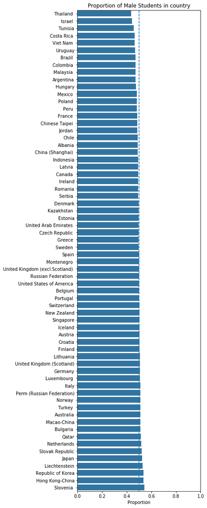

```python
#group by country get value counts per country.
df_gender_p= df_pisa_full.groupby(by="NC").ST04Q01.value_counts(normalize=True).rename("Proportion").reset_index()
#sort by proportions
df_gender_p=df_gender_p.loc[df_gender_p["ST04Q01"] == "Male",:].sort_values("Proportion")

plt.figure(figsize = [5,20 ])
base_color = sns.color_palette()[0]

gc = sns.barplot(x="Proportion",y="NC",data=df_gender_p,color = base_color)
gc.axvline(0.5, ls='--')
gc.set_xlim(0,1)
plt.title("Proportion of Male Students in country")
plt.ylabel("")
```

### Now find features correlated with Gender:

```python
#make correlation matrix
corrMatrix_full = df_pisa_full.corr()
```

```python
#Get all variables that have a correlation above 0.07 with "male".
male_corr = corrMatrix_full.Male[abs(corrMatrix_full.Male) > 0.10]
#get list of columns
col_list_mc = male_corr.index.tolist()
```

```python
#extend list to include science and maths scpres
col_list_mc.extend(["PV5SCIE","PV5MATH"])
col_list_mc.sort()
```

```python
#make correlation matrix
corrMatrix_gender = df_pisa_full[col_list_mc].corr()
```

```
(14.5, -0.5)
```

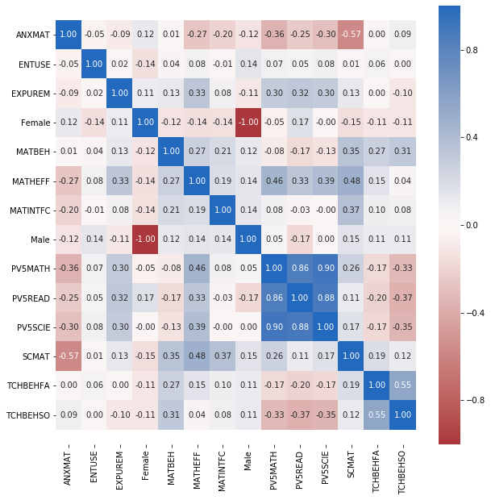

```python
#plot heatmap of features correlated with gender
plt.figure(figsize = [10,10])

#ht =sns.clustermap(corrMatrix_gender, annot = True)
ht = sns.heatmap(corrMatrix_gender, annot = True,cmap = 'vlag_r',fmt = '.2f',center = 0)
ht.set_ylim(len(corrMatrix_gender)+0.5, -0.5)
```

##### Mathanxiety and other Math related features correlated with gender

After finding features that have at least a 0.1 correlation with gender we can observe a few interesting things that may be worth looking more closely into. While a correlation of 0.1 is quite low, we generally would not expect to see very high associations with gender gloabally.  
As our questions become more specific we would expect correlations to also go up.

Interestingly Mathanxiety was also associated with reading (-25) and science (-0.3) scores. It might be that mathanxiety is a good proxy for general feelings of anxiety and underperformance.

We also find correlations with MATHBEH (math behaviour), MATHEFF (self eficacy), MATHINTFC (intentions) and SCMAT (math self concept). All of these show a trend in favour of male students.  
EXPUREM (experience with pure mathematics at school) was the only math related feature that was correlated positive with female students.

##### Gender and Reading + Science

We do not find a difference due to gender in the Science exam (PV5SCIE), but we do find a positive correlation between gender and reading ability PV5READ.

##### Gender and Teachers

Teacher behaviour is capturued in two featues these are TCHBEHFA (Formative assesment) and TCHBEHSO (student orientation). Both were negatively correlated with being female.

##### Tech and Gender

ENTUSE (ICT entertainment) is positeviely correlated with being male. (ICT = information and comunication technology)

##### Questions to think about:

1: Are Maths gender differences constant across countries? 2: Are Reading gender difference constant across countries? 3: Why is there a reading gap between male and female students? 4: What is reading score correlated with?

### Compare Mathanxiety, Maths, Reading and Science Scores:

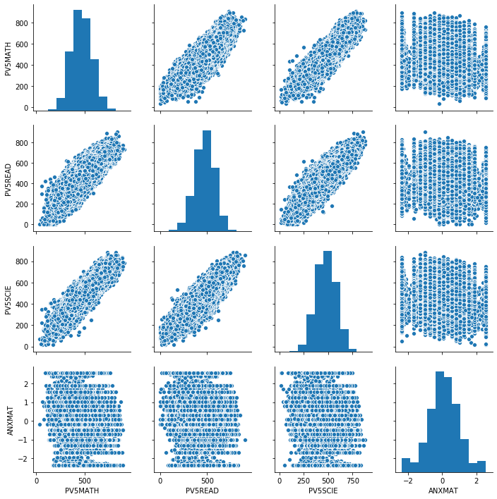

```python
#Plot Maths, Reading and Science scores

#select test scores for math, reading and science
#make pairplot
sns.pairplot(df_pisa_full.loc[:,["PV5MATH","PV5READ","PV5SCIE","ANXMAT"]])
```

As would be expected there is a pretty strong relationship between the performance for maths, science and reading.

For mathanxiety we previously saw a relatively moderate corrlation with Math, reading and science scores. However this is not very obvious from the pairplot. This is not entirely surprising, since there are liekly huge variations to performance based on country, wealth and many other factors.

I will try to find the countries that have the highest gender differences in math, reading and science, and then subset to countries of interest.

### Investigate Countries by difference in mean scores for maths, sciene and reading by gender.

```python
#calculate mean score for men, mean score for women, and difference.
#df_mean_diff_maths= pa
df_gm_mean = df_pisa_full[["PV5MATH","PV5READ","PV5SCIE","ST04Q01","NC"]].groupby(by=["NC","ST04Q01"]).mean().reset_index()
#pivot to have seperate gender columns
df_gm_math_diff=df_gm_mean.pivot(index="NC",columns='ST04Q01', values=["PV5MATH","PV5READ","PV5SCIE"])
#calculate mean score across subjects for each country. (Row mean)
df_gm_math_diff["Mean_score"]= df_gm_math_diff.mean(axis=1)
#assign ranks based on mean score
df_gm_math_diff["Mean_score_rank"]= df_gm_math_diff.Mean_score.rank(ascending =False)
#loop through all 3 categories
for i_col in ["PV5MATH","PV5READ","PV5SCIE"]:
    #for each category mean male - mean female
    df_gm_math_diff[i_col+'_gdiff']=df_gm_math_diff[i_col]["Male"]-df_gm_math_diff[i_col]["Female"]
df_gm_math_diff.head()
```

| ST04Q01 NC | PV5MATH Female | PV5MATH Male | PV5READ Female | PV5READ Male | PV5SCIE Female | PV5SCIE Male | Mean_score | Mean_score_rank | PV5MATH_gdiff | PV5READ_gdiff | PV5SCIE_gdiff |
| --- | --- | --- | --- | --- | --- | --- | --- | --- | --- | --- | --- |
| Albania | 394.070545 | 393.986860 | 401.864369 | 388.563831 | 401.291928 | 395.587838 | 395.894228 | 60.0 | -0.083685 | -13.300538 | -5.704091 |
| Argentina | 390.201618 | 402.149908 | 422.162696 | 384.314735 | 413.934190 | 407.399450 | 403.360433 | 58.0 | 11.948290 | -37.847961 | -6.534740 |
| Australia | 487.216369 | 498.869863 | 518.067958 | 484.585600 | 509.161354 | 514.115121 | 502.002711 | 24.0 | 11.653494 | -33.482358 | 4.953768 |
| Austria | 497.067225 | 518.847001 | 510.935047 | 473.122482 | 503.999524 | 512.752693 | 502.787329 | 23.0 | 21.779776 | -37.812565 | 8.753170 |
| Belgium | 516.286821 | 522.436057 | 528.003131 | 496.247332 | 509.619607 | 510.673243 | 513.877699 | 17.0 | 6.149236 | -31.755800 | 1.053636 |

Created new dataframe that countains Average scores broken down by gender, overall mean score, and differences in scores between gender (male - female score)

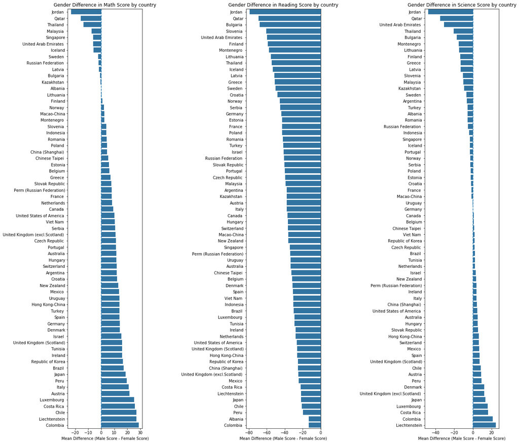

```python
plt.figure(figsize = [20,20 ])

# left plot
Gender_diff="PV5MATH_gdiff"
plt.subplot(1,5, 1)
gc = sns.barplot(x=Gender_diff,y="NC",data=df_gm_math_diff.sort_values(Gender_diff).reset_index(),color = base_color)
gc.axvline(0, ls='--')
plt.title("Gender Difference in Math Score by country")
plt.ylabel("")
plt.xlabel("Mean Difference (Male Score - Female Score)")

# middle plot
Gender_diff="PV5READ_gdiff"
plt.subplot(1,5, 3)
gc = sns.barplot(x=Gender_diff,y="NC",data=df_gm_math_diff.sort_values(Gender_diff).reset_index(),color = base_color)
gc.axvline(0, ls='--')
plt.title("Gender Difference in Reading Score by country")
plt.ylabel("")
plt.xlabel("Mean Difference (Male Score - Female Score)")

# right plot

Gender_diff="PV5SCIE_gdiff"
plt.subplot(1,5, 5)
gc = sns.barplot(x=Gender_diff,y="NC",data=df_gm_math_diff.sort_values(Gender_diff).reset_index(),color = base_color)
gc.axvline(0, ls='--')
plt.title("Gender Difference in Science Score by country")
plt.ylabel("")
plt.xlabel("Mean Difference (Male Score - Female Score)")
```

The above are plots of the mean difference in score between male and female students. Negative scores indicate higher mean scores for females in that country, while positive scores indicate higer scores for male students in that country.

##### Maths

We can see higher average maths scores for female students in Jordan, Qatar, Thailand, Malaysia, Singapore, UAE, Iceland etc.

1. Do girls have less math anxiety in these countries?
2. What is the difference between countries were girls outperform boys in maths?

##### Reading

We can see that female students do better in reading in every single country since all values are negative.

##### Science

We can see that even though male and female students perform similairy in science globally, there are local differences. For example male students outperform women in Lichtenstein, Colombia, Costa Rica, Luxenbourh, Japan, UK etc. But female students outperform in Jordan, Qatar, the UAE etc.

1. Why do women seem to outperform male students by such a high rate in all subjects in Jordan and Qatar?

In the case of Jordan, it seems like there is a well documented achievement gap in favour of female students. https://www.researchgate.net/publication/281280418_Gender_Gap_in_Student_Achievement_in_Jordan_Study_Report

### Plot countries by overall mean score across all subjects:

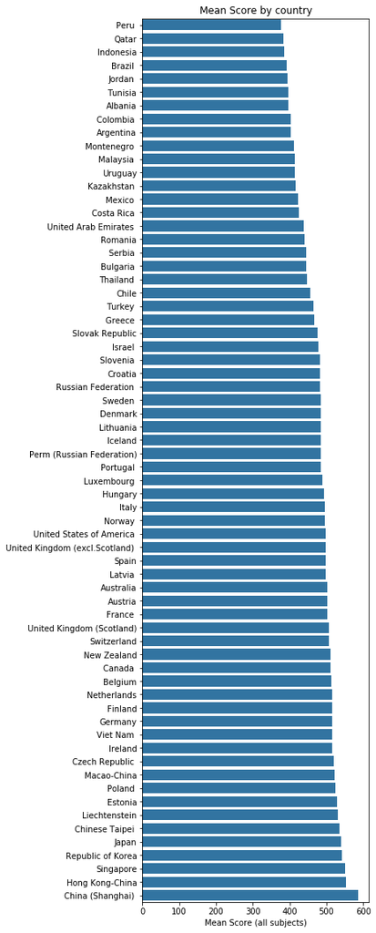

```python
plt.figure(figsize = [5,20 ])
gc = sns.barplot(x="Mean_score",y="NC",data=df_gm_math_diff.sort_values("Mean_score").reset_index(),color = base_color)
plt.title("Mean Score by country")
plt.ylabel("")
plt.xlabel("Mean Score (all subjects)")
```

Jordan is overall the fith worst performing country. There might be some structureal issues unique to Jordan that lead to female students outperforming male students in all subjects.

### Split countries into Low, Medium and High achievement countries.

```python
#bin by achievement for each country
df_gm_math_diff["Achievement_bins"] = pd.qcut(df_gm_math_diff.Mean_score, 3, labels=["Low","Medium","High"])
```

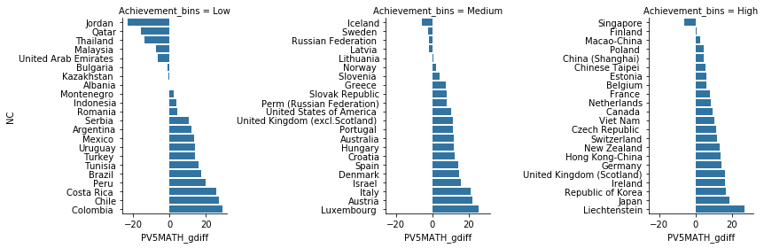

```python
# split by
Gender_diff="PV5MATH_gdiff"
g = sns.FacetGrid(data = df_gm_math_diff.sort_values(Gender_diff).reset_index(), col = "Achievement_bins", size = 4,sharey=False)
g.map(sns.barplot, Gender_diff, "NC")
```

This plot shows again that Jordan and Qatar have the highest gendergap in maths in favour girls. But both of them are in the lowest thrid of overall perfomance. In high performance countries only Singapore shows women outperfoming boys in maths.

In order to look more closely at associations in interesting countries I will subset to 6 countries with high gender differences in maths. 2 for each of the above categories.

I will use Jordan, Iceland and Singapore as countries where female students outperform male students and Columbia, Austria and Japan as countries where male students outperform.

### Further Exploration of 6 Key countries with high Gender Differences:

#### Subset to countries

```python
### list of interesting countries
country_list = ['Jordan ', 'Iceland','Singapore','Japan','Colombia ','Austria',]
#subset main df to interesting countries.
df_pisa = df_pisa_full[df_pisa_full['NC'].isin(country_list)]
#Change country names
df_pisa.NC.replace(country_list, ['Jordan', 'Iceland','Singapore','Japan','Colombia','Austria'],inplace=True)
```

```python
df_pisa_full.NC.value_counts().index.tolist
```

```
<bound method IndexOpsMixin.tolist of Index(['Mexico ', 'Italy', 'Spain', 'Canada ', 'Brazil ', 'Australia',
       'United Arab Emirates ', 'Switzerland', 'Qatar',
       'United States of America ', 'United Kingdom (excl.Scotland) ',
       'Colombia ', 'Finland', 'Belgium', 'Denmark', 'Jordan ', 'Chile',
       'Thailand ', 'Japan', 'Chinese Taipei ', 'Peru ', 'Slovenia ',
       'Argentina', 'Kazakhstan ', 'Portugal ', 'Indonesia', 'Singapore',
       'Macao-China', 'Czech Republic ', 'Uruguay', 'Bulgaria ', 'Luxembourg ',
       'Russian Federation ', 'Malaysia ', 'China (Shanghai) ', 'Greece ',
       'Romania', 'Israel ', 'Republic of Korea', 'Ireland', 'Croatia',
       'Germany', 'Viet Nam ', 'Turkey ', 'Hungary', 'Estonia', 'Austria',
       'Montenegro ', 'Albania', 'Sweden ', 'Norway ', 'Serbia ',
       'Slovak Republic', 'Hong Kong-China', 'Lithuania', 'France ', 'Poland ',
       'Costa Rica ', 'Netherlands', 'Tunisia', 'Latvia ', 'New Zealand',
       'Iceland', 'United Kingdom (Scotland)', 'Perm (Russian Federation)',
       'Liechtenstein'],
      dtype='object')>
```

### Check Wealth and Mathanxiety distributions by Country

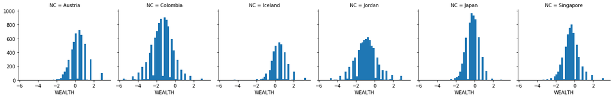

```python
bin_edges = np.arange(df_pisa['WEALTH'].min(), df_pisa['WEALTH'].max()+1/5, 1/5)
g = sns.FacetGrid(data = df_pisa, col = 'NC')
g.map(plt.hist, "WEALTH", bins = bin_edges)
```

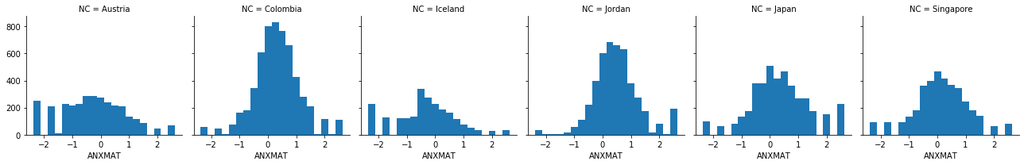

```python
bin_edges = np.arange(df_pisa['ANXMAT'].min(), df_pisa['ANXMAT'].max()+1/4, 1/4)
g = sns.FacetGrid(data = df_pisa, col = 'NC')
g.map(plt.hist, "ANXMAT", bins = bin_edges)
```

The biggest spreads of wealth are in columbia and Jordan. Mathanxiety is a relatively normally distributed in Columbia and Jordan, but is more shifted towards the lower end in Iceland and Austria.

## Multivariate Exploration

### Scatterplots of wealth vs P5 Mathscore split by countries and gender

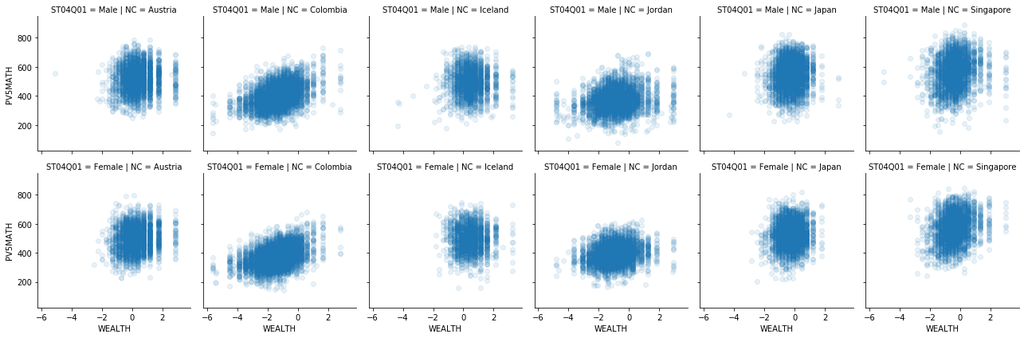

```python
g = sns.FacetGrid(data = df_pisa, col = country, row=gender, size = 3)
g.map(sns.regplot, "WEALTH", score, fit_reg = False, scatter_kws = {'alpha' : 1/10})
```

There does seem to be a relationship between wealth and mathscore allthough it varies from country to country. Jordana nd Columbia are the worst performing countries in average maths score, and they have the largest wealth gap internally. Richer countries like Austria, Japan and Iceland look more equal. Singapore seems like it has more of an associated between wealth and academic score.

### Scatterplots of Mathanxiety vs Mathscore by country and gender.

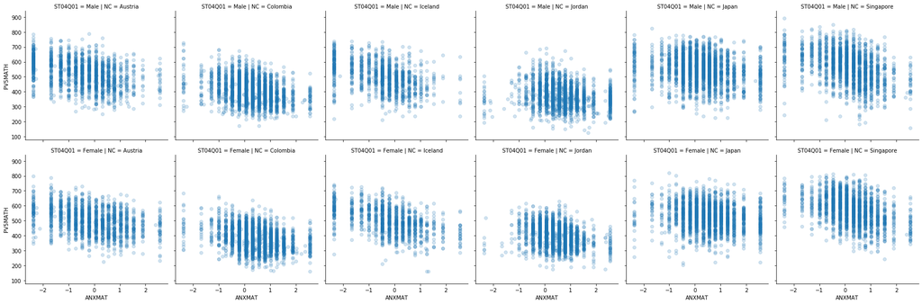

```python
g = sns.FacetGrid(data = df_pisa, col = country, row=gender, size = 4)
g.map(sns.regplot, "ANXMAT", score,  fit_reg = False, scatter_kws = {'alpha' : 1/5})
```

It is a bit easier to see associations between mathanxiety and mathscore here.

Increase in wealth seems to lead to better maths scores at least in Japan and Singapore.

An increase in math anxiety reduces math performance somewhat. Which would be expected.

### Sense of belonging by Country and Gender

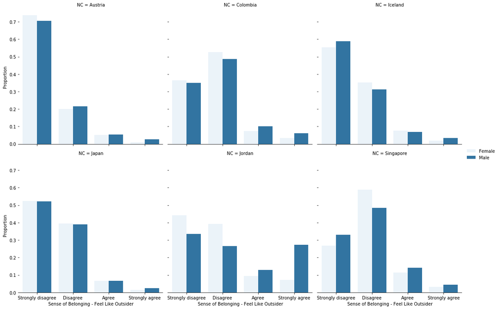

```python
#get columns to plot
temp_var="ST87Q01"

#define category order
cat_order= ['Strongly disagree', 'Disagree','Agree','Strongly agree']
#plt.figure(figsize = [20,20])

#get proportion for
temp_df=df_pisa.groupby(["NC","ST04Q01"])[temp_var].value_counts(normalize=True).rename("Proportion").reset_index()
temp_df

g = sns.catplot(data=temp_df, x="ST87Q01", y="Proportion", hue="ST04Q01",
                col="NC", kind='bar',order=cat_order,col_wrap=3,
                sharex=True,sharey=True,color = base_color,legend=False)
g.add_legend()
#g.plt.xlabel("Sense of Belonging - Feel Like Outsider")
(g.set_axis_labels("Sense of Belonging - Feel Like Outsider","Proportion")
   .despine(left=True))
```

Jordan has the highest proportion of students that say they "strongly agree" with "feeling like an outsider at school". Even more interestingly is that the vast majority of students who feel this way are male.

### Attitude to School by country and gender:

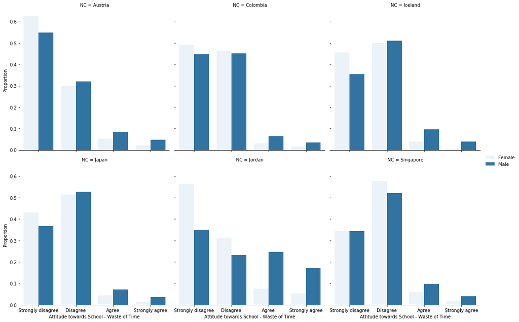

```python
#get columns to plot
temp_var="ST88Q02"
gender ="ST04Q01"
#define category order
cat_order= ['Strongly disagree', 'Disagree','Agree','Strongly agree']


#get proportion for
temp_df=df_pisa.groupby(["NC",gender])[temp_var].value_counts(normalize=True).rename("Proportion").reset_index()


g = sns.catplot(data=temp_df, x=temp_var, y="Proportion", hue=gender,
                col="NC", kind='bar',order=cat_order,col_wrap=3,
                sharex=True,sharey=True,color = base_color,legend=False)
g.add_legend()
#g.plt.xlabel("Sense of Belonging - Feel Like Outsider")
(g.set_axis_labels("Attitude towards School - Waste of Time","Proportion")
   .despine(left=True))
```

Jordan has the highest proportion of students who feel that school is a waste of time. Again this is because of male students. Female students are in line with attitudes in oter countries.

### Boxplots of mathscore vs belonging in key countries by gender

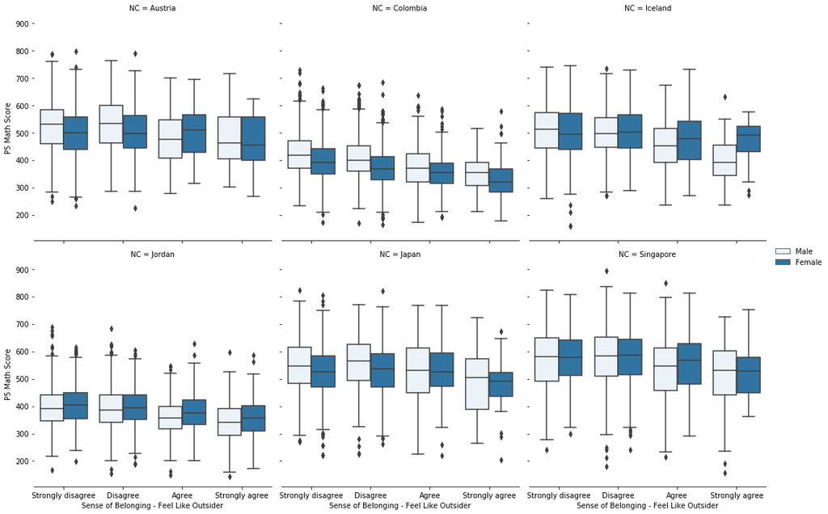

```python
### Make boxplots by country
gender="ST04Q01"
country="NC"
score="PV5MATH"


g = sns.catplot(data=df_pisa, x="ST87Q01", y=score, hue=gender,
                col="NC", kind='box',col_wrap=3, sharex=True,sharey=True,color = base_color,legend=False)
g.add_legend()
#g.plt.xlabel("Sense of Belonging - Feel Like Outsider")
(g.set_axis_labels("Sense of Belonging - Feel Like Outsider","P5 Math Score")
   .despine(left=True))
```

The boxplots show that there is a relationship between math test score and sense of belonging at school. It also shows that girls in jordan outperfom boys regardless of their sense of belonging. This is the exact oppositie in Columbia. Interstingly when looking at iceland we see that girls who strongly feel like outsiders do much better than boys in the same situation.

In Jordan we see a higher median for girls, but interestingly a lot more extreme outliers for boys in both directions.

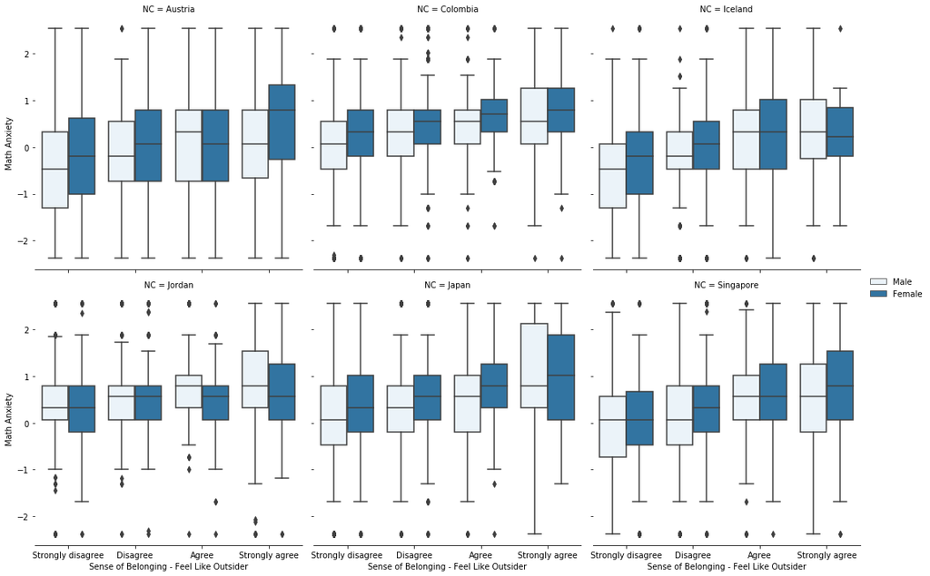

```python
### Make boxplots by country
gender="ST04Q01"
country="NC"
score="ANXMAT"


g = sns.catplot(data=df_pisa, x="ST87Q01", y=score, hue=gender,
                col="NC", kind='box',col_wrap=3, sharex=True,sharey=True,color = base_color,legend=False)
g.add_legend()
#g.plt.xlabel("Sense of Belonging - Feel Like Outsider")
(g.set_axis_labels("Sense of Belonging - Feel Like Outsider","Math Anxiety")
   .despine(left=True))
```

Interestingly a decrease in sense of belonging does not seem to increase math anxiety in jordanian girls, but does affect male students.

### Reading Score vs Number of Books at home broken down by country and gender.

```python
#make book categories
book_classes = ['0-10 books ','11-25 books ','26-100 books ', '101-200 books ','201-500 books ', 'More than 500 books']
bclasses = pd.api.types.CategoricalDtype(ordered = True, categories = book_classes)
df_pisa.ST28Q01 = df_pisa.ST28Q01.astype(bclasses)
#replace categories
df_pisa.ST28Q01.cat.rename_categories(["0-10","11-25","26-100","101-200","201-500","500+"],inplace=True)
```

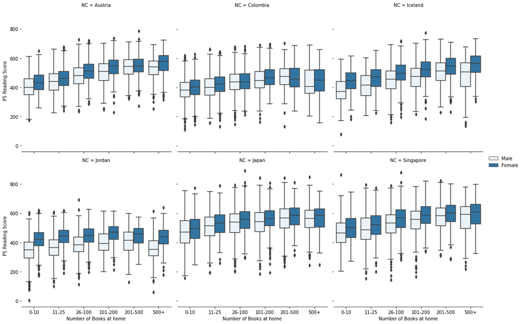

```python
n_books = "ST28Q01"
read_score = "PV5READ"

g = sns.catplot(data=df_pisa, x=n_books, y=read_score, hue=gender,
                col="NC", kind='box',col_wrap=3, sharex=True,sharey=True,color = base_color,legend=False)
g.add_legend()
#g.plt.xlabel("Sense of Belonging - Feel Like Outsider")
(g.set_axis_labels("Number of Books at home","P5 Reading Score")
   .despine(left=True))
```

The number of books at home is assumed to be correlated with reading score in all countries. This was true for most countries except maybe for jordan.

## Jordan Closer Look:

I was curious to look more closely at Jordan in paticulair. The analysis below is just subset to jordan.

```python
df_jordan=df_pisa_full.loc[df_pisa_full["NC"] == "Jordan ",]
#make correlation matrix
corrMatrix_jordan = df_jordan.corr()
```

```python
#Get all variables that have a correlation above 0.07 with "male".
male_corr_j = corrMatrix_jordan.Male[abs(corrMatrix_jordan.Male) > 0.15]
#get list of columns
col_list_j = male_corr_j.index.tolist()
#make correlation matrix
corrMatrix_jordan2 = df_jordan[col_list_j].corr()
```

```
(17.5, -0.5)
```

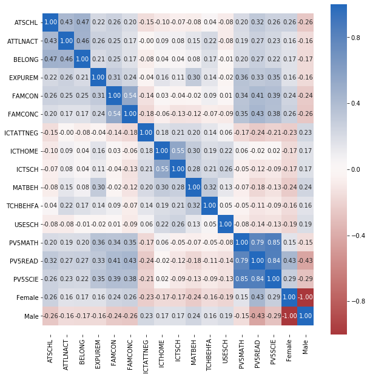

```python
#plot heatmap of features correlated with gender
plt.figure(figsize = [10,10])


ht = sns.heatmap(corrMatrix_jordan2, annot = True,cmap = 'vlag_r',fmt = '.2f',center = 0)
ht.set_ylim(len(corrMatrix_jordan2)+0.5, -0.5)
```

##### Gender differences in Jordan:

Neagative correlation between being male and Math, Reading and Science scores.

Male students also have negative correlation with Attitude towards school (ATSCHL & ATTLNACT).

Sense of belonging (BELONG) is negatively correlated with male students.

They have more availablity of computers at school and at home ('ICTHOME', 'ICTSCH',) but also see the computer as less helpful for learning ('ICTATTNEG'), use of computer at school is also positively correlated with being male. ('USESCH')

Mathematics behaviour is positevely correlated with being male, as is teacher behvariour towards formative assements.

### Sense of Belonging Question broken down by gender in Jordan:

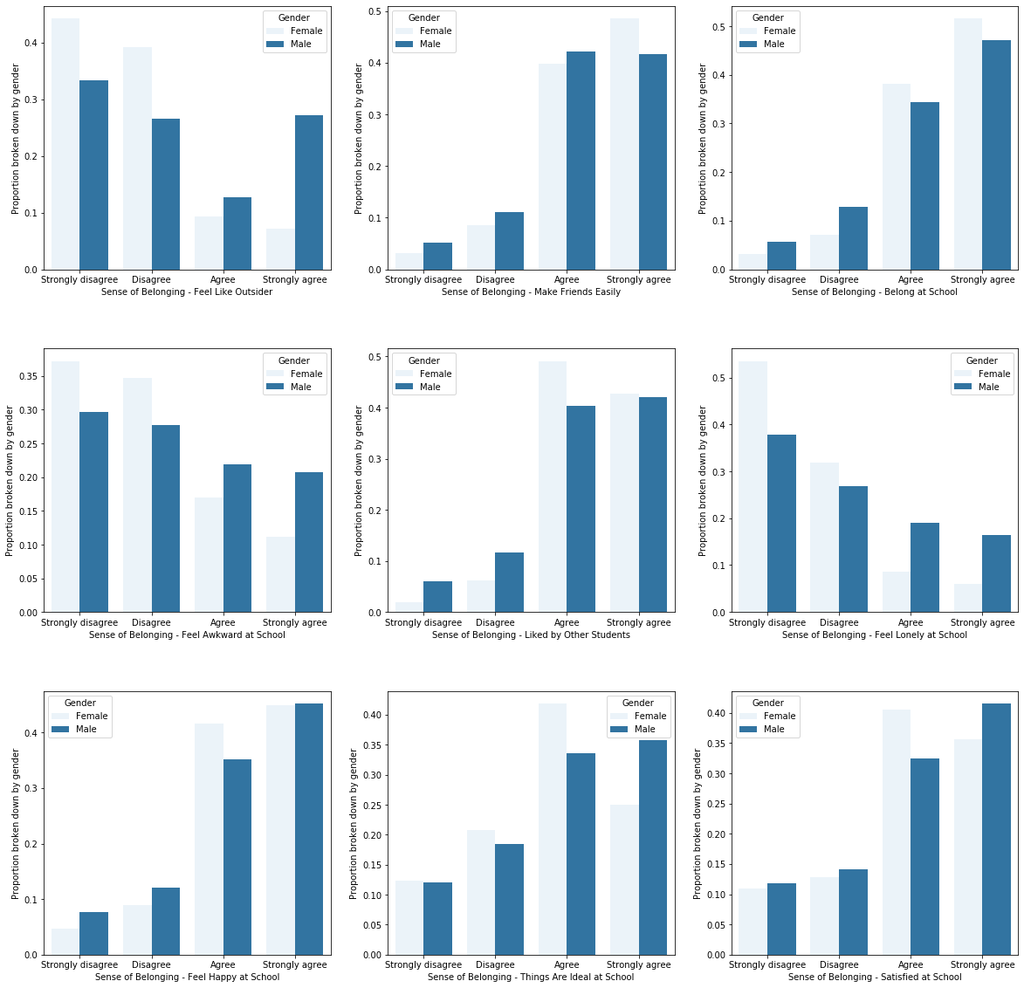

```python
#get columns to plot
x_val_list=df_jordan.loc[:,"ST87Q01":"ST87Q09"].columns
n=len(x_val_list)

#define category order
cat_order= ['Strongly disagree', 'Disagree','Agree','Strongly agree']
plt.figure(figsize = [20,20 ])

for i in range(n):
    #make temp var
    temp_var=x_val_list[i]
    #get variable definition from temp variable
    var_def = df_pdic.loc[df_pdic.column_names == temp_var,"definition"].to_list()
    #make temp df that contains protoprition value counts
    temp_df=df_jordan.groupby(gender)[temp_var].value_counts(normalize=True).rename("Proportion").reset_index()
    plt.subplot(3,3,i+1)
    plt.subplots_adjust(hspace = .3)
    sns.barplot(x=temp_var,y="Proportion",data=temp_df,color = base_color,hue=gender,order=cat_order)
    plt.legend(title='Gender')
    plt.xlabel(var_def[0])
    plt.ylabel("Proportion broken down by gender")
```

Male students in Jordan were more liekly to feel like an outsider, and feel akward and feel lonely at school. Despite this males were more liekly to agree strongly that "things are ideal at school"

### Percieved Control Question broken down by gender in Jordan:

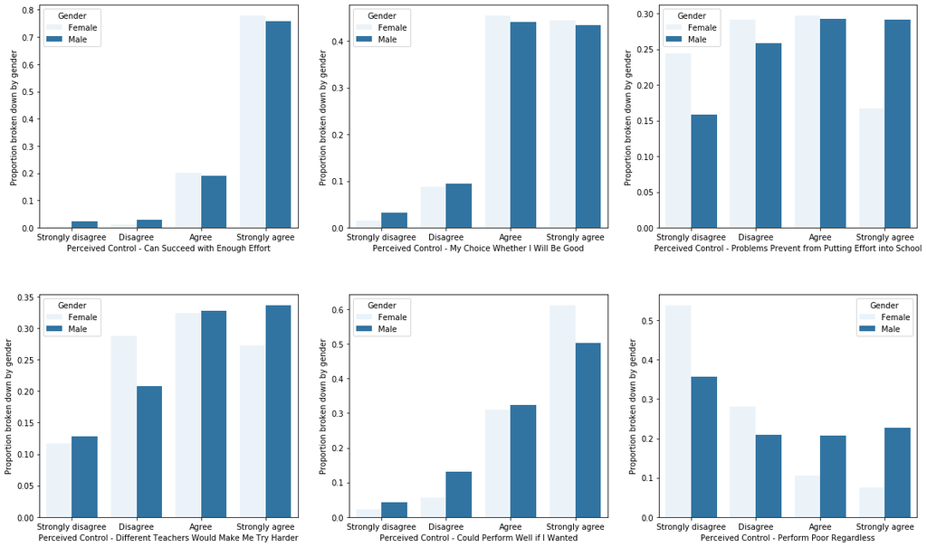

```python
#get columns to plot
x_val_list=df_jordan.loc[:,"ST91Q01":"ST91Q06"].columns
n=len(x_val_list)

#define category order
cat_order= ['Strongly disagree', 'Disagree','Agree','Strongly agree']
plt.figure(figsize = [20,12 ])

for i in range(n):
    #make temp var
    temp_var=x_val_list[i]
    #get variable definition from temp variable
    var_def = df_pdic.loc[df_pdic.column_names == temp_var,"definition"].to_list()
    #make temp df that contains protoprition value counts
    temp_df=df_jordan.groupby(gender)[temp_var].value_counts(normalize=True).rename("Proportion").reset_index()
    plt.subplot(2,3,i+1)
    plt.subplots_adjust(hspace = .3)
    sns.barplot(x=temp_var,y="Proportion",data=temp_df,color = base_color,hue=gender,order=cat_order)
    plt.legend(title='Gender')
    plt.xlabel(var_def[0])
    plt.ylabel("Proportion broken down by gender")
```

Males in Jordan have lower feelings of control. They feel they are liekly to perform poorly regardless of what happens.

### Perseverance Question broken down by gender in Jordan:

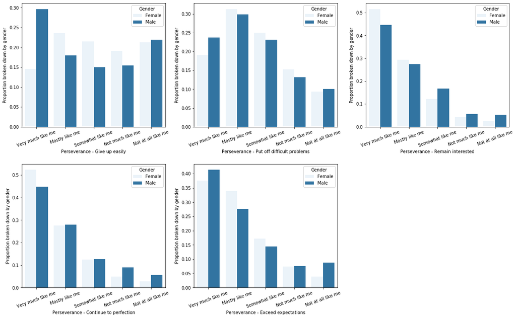

```python
#get columns to plot
x_val_list=df_jordan.loc[:,"ST93Q01":"ST93Q07"].columns
n=len(x_val_list)

#define category order
cat_order= ['Very much like me','Mostly like me','Somewhat like me','Not much like me','Not at all like me']




plt.figure(figsize = [20,12 ])

for i in range(n):
    #make temp var
    temp_var=x_val_list[i]
    #get variable definition from temp variable
    var_def = df_pdic.loc[df_pdic.column_names == temp_var,"definition"].to_list()
    #make temp df that contains protoprition value counts
    temp_df=df_jordan.groupby(gender)[temp_var].value_counts(normalize=True).rename("Proportion").reset_index()
    plt.subplot(2,3,i+1)
    plt.subplots_adjust(hspace = .3)
    sns.barplot(x=temp_var,y="Proportion",data=temp_df,color = base_color,hue=gender,order=cat_order)
    plt.xticks(rotation = 20)
    plt.legend(title='Gender')
    plt.xlabel(var_def[0])
    plt.ylabel("Proportion broken down by gender")
```

Jordanian boys say they are much more liekly to give up easily and girls.

### Attitudes Towards School Question broken down by gender in Jordan:

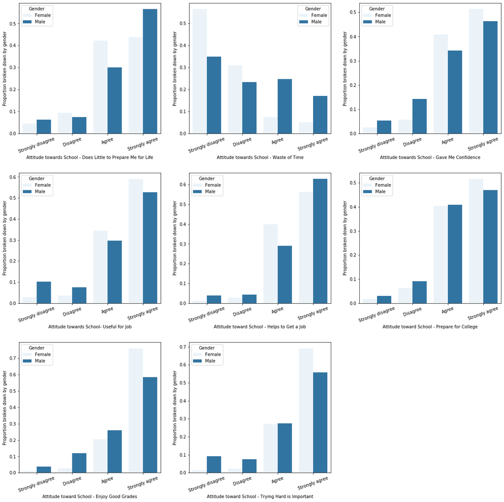

```python
#get columns to plot
x_val_list=df_jordan.loc[:,"ST88Q01":"ST89Q05"].columns
n=len(x_val_list)

#define category order
cat_order= ['Strongly disagree', 'Disagree','Agree','Strongly agree']




plt.figure(figsize = [20,20 ])

for i in range(n):
    #make temp var
    temp_var=x_val_list[i]
    #get variable definition from temp variable
    var_def = df_pdic.loc[df_pdic.column_names == temp_var,"definition"].to_list()
    #make temp df that contains protoprition value counts
    temp_df=df_jordan.groupby(gender)[temp_var].value_counts(normalize=True).rename("Proportion").reset_index()
    plt.subplot(3,3,i+1)
    plt.subplots_adjust(hspace = .3)
    sns.barplot(x=temp_var,y="Proportion",data=temp_df,color = base_color,hue=gender,order=cat_order)
    plt.xticks(rotation = 20)
    plt.legend(title='Gender')
    plt.xlabel(var_def[0])
    plt.ylabel("Proportion broken down by gender")
```

Jordanian boys are elss liekly to agree that trying hard is important, or that they enjoy getting good grades.